# CM3015 MLNN - Final

## 1. Defining the problem and assembling a dataset

**What is the input data?**

The selected input data for this machine learning problem will be the IMDB movieset from keras.datasets. The dataset contains 50,000 reviews split into train and test batches. Each batch contains 25,000 reviews. The reviews are labeled as positive or negative in a ratio of 50/50. The reviews have also been preprocessed with each review encoded as a list of word indexes.

For the collection of the data method of the data from the IMDB website, each movie will have a maximum of 30 reviews. The negative labeled reviews have a score of <= 4/10, and the positive reviews are scored >= 7/10. This helps to ensures that the reviews that are more neutral are not included.

For the purpose of this project, the data (train_data, test_data) will be transformed from an array of lists representing a list of the index of words ranked in the overall frequency of the dataset (already-tokenized bag of words (BoW)), which was provided by the owners of this dataset.

The label (train_labels, test_labels) is either 0 or 1, where 0 is negative and 1 is positive.

**What type of problem?**

This type of problem is a binary classification problem. There would only be two possible outputs and that would either be 0 or 1, where 0 stands for negative and 1 stands for positive.

**What are you hoping to predict?**

Given a new or unseen movie review (according to the model), the aim is to predict if the movie reviews as positive or negative to a high level of accuracy.

The unseen movie reviews will be the separated test set, which contains 25,000 movie reviews with their correct labels. After finding the best performing model, we will evaluate with the test set to see the performance.

## 2. Choosing a measure of success

Accuracy will be the main measure of success for the model. The reason is because in this binary classification we can only have 2 outcomes either positive or negative label. Accuracy measures how often the classifier predicts the correct label. The reference for the baseline model will be based on accuracy score.

A confusion matrix for step 8 (testing) will be created and plotted, which will also let us visualize the performance of the model and provide us with more metrics such as precision, recall, and f1-score. These metrics will allow us to further example how the model performs in the context of predicting the labels.

## 3.Deciding on an evaluation protocol

The evaluation method used is the hold-out validation. Before we train the model, we will take the training data and training labels to split into a partial train and validation train set. The validation set will include 10,000 samples, and the partial train will include the remaining 15,000 samples.

This method will allow us to train the model with the partial train data, and monitor the performance (loss and accuracy) of the model by running a validation set after training. This will allow us to fine tune the parameters before fully testing it on the unseen test set.

The advantage of this is that we can get a preliminary view into how the model will perform on unseen data. Since the dataset is quite large with enough samples (25,000 for train, 25,000 for test), the hold-out validation method is a good choice.

## 4. Preparing your data

#### Import libraries and load dataset

```python
#import libraries
import os
import numpy as np
import matplotlib.pyplot as plt
from sklearn.metrics import classification_report
import seaborn as sns

import tensorflow as tf
import tensorflow_hub as hub
import tensorflow_datasets as tfds
from keras import models
from keras import layers
from keras import optimizers
from keras import losses
from keras import metrics
from keras import regularizers
```

```python
# load dataset and limit number of words to 10000
from keras.datasets import imdb
(train_data, train_labels), (test_data, test_labels) = imdb.load_data(num_words=10000)
```

#### Manipulate into tensors and normalize data

We can see that the data from the "keras.datasets import imdb" is organized into an array of lists with the shape of 25,000 items. Each list contains the number corresponding to the already-tokenized bag of words (BoW) features.

```python
train_data[0:2]
```

```
array([list([1, 14, 22, 16, 43, 530, 973, 1622, 1385, 65, 458, 4468, 66, 3941, 4, 173, 36, 256, 5, 25, 100, 43, 838, 112, 50, 670, 2, 9, 35, 480, 284, 5, 150, 4, 172, 112, 167, 2, 336, 385, 39, 4, 172, 4536, 1111, 17, 546, 38, 13, 447, 4, 192, 50, 16, 6, 147, 2025, 19, 14, 22, 4, 1920, 4613, 469, 4,…
       list([1, 194, 1153, 194, 8255, 78, 228, 5, 6, 1463, 4369, 5012, 134, 26, 4, 715, 8, 118, 1634, 14, 394, 20, 13, 119, 954, 189, 102, 5, 207, 110, 3103, 21, 14, 69, 188, 8, 30, 23, 7, 4, 249, 126, 93, 4, 114, 9, 2300, 1523, 5, 647, 4, 116, 9, 35, 8163, 4, 229, 9, 340, 1322, 4, 118, 9, 4, 130, 4…
      dtype=object)
```

```python
train_data.shape
```

```
(25000,)
```

Here we will use the vectorize_sequences function to encode the train and test data into a binary matrix in the size of 25,000 by 10,000. Then the training and test data will be vectorized by passing through the function that creates an all-zero matrix of the specified shape while setting specific indices to 1. This also effectively normalizes the train and test data at the same time.

The corresponding labels will also be vectorized with the np.asarray and .astype('float32').

```python
# encoding the interger into binary matrix
def vectorize_sequences(sequences, dimension=10000):
    results = np.zeros((len(sequences), dimension))
    for i, sequence in enumerate(sequences):
        results[i, sequence] = 1.
    return results

x_train = vectorize_sequences(train_data)
x_test = vectorize_sequences(test_data)

# vectorize labels
y_train = np.asarray(train_labels).astype('float32')
y_test = np.asarray(test_labels).astype('float32')
x_train.shape
```

```
(25000, 10000)
```

The end result after encoding is a 25,000 by 10,000 tensor for each train and test set. This represents the 25,000 movie reviews by the 10,000 possible words.

The input data is now prepared and in the form of vectors. The labels are scalers (1 or 0). Everything is now ready for the next step.

## 5. Developing a model that does better than a baseline

**Common-sense baseline:**

For this dataset, the positive and negative review labels are at a ratio of 50/50 each. So, the baseline common sense would be to beat 50% and we will aim to create a model that achieve slightly over that.

#### The smallest model that beats common-sense baseline

We will create a model with 2 sequential hidden layers, each with relu activation functions. The first layer will have 4 hidden units and the second will have 2 hidden units.

For loss function, we will select the binary_crossentropy. rmsorop will be the optimizer and accuracy will be observed during training. All these parameters are recommended in DLWP Chapter 3.4.

We will also set aside the validation set with 10,000 samples from the train set, leaving 15,000 samples as the partial train set.

```python
# split validation set
x_val = x_train[:10000]
partial_x_train = x_train[10000:]
y_val = y_train[:10000]
partial_y_train = y_train[10000:]

# define model
model = models.Sequential()
model.add(layers.Dense(4, activation='relu', input_shape=(10000,)))
model.add(layers.Dense(2, activation='relu'))

# compile model
model.compile(optimizer='rmsprop',
loss='binary_crossentropy',
metrics=['accuracy'])
model.summary()
```

```
Model: "sequential"
_________________________________________________________________
 Layer (type)                Output Shape              Param #
=================================================================
 dense (Dense)               (None, 4)                 40004

 dense_1 (Dense)             (None, 2)                 10

=================================================================
Total params: 40014 (156.30 KB)
Trainable params: 40014 (156.30 KB)
Non-trainable params: 0 (0.00 Byte)
_________________________________________________________________
```

```python
#train mode and evaluate with test set
history = model.fit(partial_x_train,
    partial_y_train,
    epochs=5,
    batch_size=512,
    validation_data=(x_val, y_val), verbose=0)
#get results of model with test data
results = model.evaluate(x_test, y_test)
model.reset_states()
```

[output not shown]

**Results of the baseline model:**

We can see that the reported numbers after training and evaluating returns 2 metrics:

So far, the accuracy is slightly above our baseline of 50%. And that should be a good starting point for expanding the model.

```python
#get history
history_dict = history.history
history_dict.keys()
```

```
dict_keys(['loss', 'accuracy', 'val_loss', 'val_accuracy'])
```

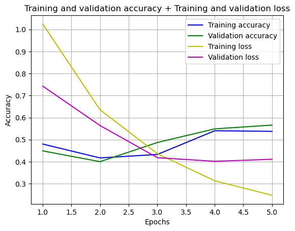

```python
# Let's plot training and validation accuracy as well as loss.
def plot_history(history):
    accuracy = history.history['accuracy']
    val_accuracy = history.history['val_accuracy']
    loss = history.history['loss']
    val_loss = history.history['val_loss']
    epochs = range(1,len(accuracy) + 1)

    # Plot accuracy
    plt.figure(1)
    plt.plot(epochs, accuracy, 'b', label='Training accuracy')
    plt.plot(epochs, val_accuracy, 'g', label='Validation accuracy')
    plt.plot(epochs, loss, 'y', label='Training loss')
    plt.plot(epochs, val_loss, 'm', label='Validation loss')
    plt.title('Training and validation accuracy + Training and validation loss')
    plt.xlabel('Epochs')
    plt.ylabel('Accuracy')
    plt.grid()
    plt.legend()
plot_history(history)
```

**Training data interpretation - accuracy and loss**

From the plot, we can see that the training and validation accuracy starts at below 0.5, then rises slightly above the baseline and then settles in at around 0.55. This is similar to the result when we run model.evaluate to test the model on the test set.

Loss for both training and validation is steadily decreasing but hints at a divergence at around 3 epochs.

Overall, the performance is not great, but able to meet the requirements of a small baseline model.

## 6. Scaling up: developing a model that overfits

We will start by creating a function to run multiple models sequentially with different parameters. This will speed up the process of testing and interpreting the results. Overall, this allows us to test different batches of configurations with less lines of code as it will be modular.

**3 layer model with differing hidden units per layer**

We will start off with a 3 layer model consisting of 2 relu layers and ending in 1 sigmoid layer. We will first explore the effect of network size in relation to the hidden units per layer starting with 16 units and ending in 256 units.

```python
# define function that can run sequential models back to back
def build_model(layer_1_units, layer_2_units, layer_3_units):
    model = models.Sequential()
    model.add(layers.Dense(layer_1_units, activation='relu', input_shape=(10000,)))
    model.add(layers.Dense(layer_2_units, activation='relu'))
    model.add(layers.Dense(layer_3_units, activation='sigmoid'))
    model.compile(optimizer='rmsprop',
        loss='binary_crossentropy',
        metrics=['accuracy'])
    return model

class CustomCallback(tf.keras.callbacks.Callback):
    def on_epoch_begin(self, epoch, logs=None):
        c = ['\b|', '\b/', '\b-', '\b\\']
        print(c[epoch % 4], end='')
    def on_epoch_end(self, epoch, logs=None):
        print('\b', end='')
```

```python
histories = {}
#can input number of hidden units for each layer. Here we will test an increasing large number of hidden units
for i in [16, 32, 64, 128, 256]:
    model = build_model(i, i, 1)
    model_name = str(i) + '-' + str(i) + '-' + str(1)
    print('Training', model_name)
    history = model.fit(partial_x_train,
                       partial_y_train,
                        epochs=20,
                        batch_size=512,
                        validation_data=(x_val, y_val),
                        verbose = 0,
                        callbacks = [CustomCallback()])
    histories[model_name] = history
    model.summary()
    model.reset_states()
```

```
Training 16-16-1
Model: "sequential_1"
_________________________________________________________________
 Layer (type)                Output Shape              Param #
=================================================================
 dense_2 (Dense)             (None, 16)                160016

 dense_3 (Dense)             (None, 16)                272

 dense_4 (Dense)             (None, 1)                 17

=================================================================
Total params: 160305 (626.19 KB)
Trainable params: 160305 (626.19 KB)
Non-trainable params: 0 (0.00 Byte)
_________________________________________________________________
Training 32-32-1
Model: "sequential_2"
_________________________________________________________________
 Layer (type)                Output Shape              Param #
=================================================================
 dense_5 (Dense)             (None, 32)                320032

 dense_6 (Dense)             (None, 32)                1056

 dense_7 (Dense)             (None, 1)                 33

=================================================================
Total params: 321121 (1.22 MB)
Trainable params: 321121 (1.22 MB)
Non-trainable params: 0 (0.00 Byte)
_________________________________________________________________
Training 64-64-1
Model: "sequential_3"
_________________________________________________________________
 Layer (type)                Output Shape              Param #
=================================================================
 dense_8 (Dense)             (None, 64)                640064

 dense_9 (Dense)             (None, 64)                4160
```

[output cut: 25 more lines]

```
Model: "sequential_5"
_________________________________________________________________
 Layer (type)                Output Shape              Param #
=================================================================
 dense_14 (Dense)            (None, 256)               2560256

 dense_15 (Dense)            (None, 256)               65792

 dense_16 (Dense)            (None, 1)                 257

=================================================================
Total params: 2626305 (10.02 MB)
Trainable params: 2626305 (10.02 MB)
Non-trainable params: 0 (0.00 Byte)
_________________________________________________________________
```

```python
history_dict = history.history
history_dict.keys()
```

```
dict_keys(['loss', 'accuracy', 'val_loss', 'val_accuracy'])
```

### Modular code for plotting

```python
# plot training and validation loss helper functions for future use
acc = history_dict['accuracy']
#define training accuracy
def plot_acc_comparison(acc_a, label_a, acc_b, label_b, acc_c, label_c, acc_d, label_d, acc_e, label_e, y_label):
    epochs = range(1, len(acc) + 1)
    plt.plot(epochs, acc_a, label=label_a)
    plt.plot(epochs, acc_b, label=label_b)
    plt.plot(epochs, acc_c, label=label_c)
    plt.plot(epochs, acc_d, label=label_d)
    plt.plot(epochs, acc_e, label=label_e)
    plt.title('Accuracy')
    plt.xlabel('Epochs')
    plt.ylabel(y_label)
    plt.legend()
    plt.show()

#define validation accuracy
def plot_val_acc_comparison(val_acc_a, label_a, val_acc_b, label_b, val_acc_c, label_c, val_acc_d, label_d,val_acc_e, label_e,
                            y_label):
    epochs = range(1, len(acc) + 1)
    plt.plot(epochs, val_acc_a, label=label_a)
    plt.plot(epochs, val_acc_b, label=label_b)
    plt.plot(epochs, val_acc_c, label=label_c)
    plt.plot(epochs, val_acc_d, label=label_d)
    plt.plot(epochs, val_acc_e, label=label_e)
    plt.title('Validation accuracy')
    plt.xlabel('Epochs')
    plt.ylabel(y_label)
    plt.legend()
    plt.show()

#define validation loss
def plot_loss_comparison(loss_a, label_a, loss_b, label_b, loss_c, label_c, loss_d, label_d, loss_e, label_e, y_label):
    epochs = range(1, len(acc) + 1)
    plt.plot(epochs, loss_a, label=label_a)
    plt.plot(epochs, loss_b, label=label_b)
    plt.plot(epochs, loss_c, label=label_c)
    plt.plot(epochs, loss_d, label=label_d)
    plt.plot(epochs, loss_e, label=label_e)
    plt.title('Validation loss')
    plt.xlabel('Epochs')
    plt.ylabel(y_label)
    plt.legend()
    plt.show()

#define training loss
def plot_training_loss_comparison(tloss_a, label_a, tloss_b, label_b, tloss_c, label_c, tloss_d, label_d, tloss_e, label_e,
                                  y_label):
    epochs = range(1, len(acc) + 1)
    plt.plot(epochs, tloss_a, label=label_a)
    plt.plot(epochs, tloss_b, label=label_b)
    plt.plot(epochs, tloss_c, label=label_c)
    plt.plot(epochs, tloss_d, label=label_d)
    plt.plot(epochs, tloss_e, label=label_e)
    plt.title('Training loss')
    plt.xlabel('Epochs')
    plt.ylabel(y_label)
    plt.legend()
    plt.show()

#plot for network a
def plot_net_a(acc , label_a, val_acc , label_b, tloss, label_c, loss, label_d, y_label):
    epochs = range(1, len(acc) + 1)
    plt.plot(epochs, acc, 'b', label=label_a)
    plt.plot(epochs, val_acc, 'g', label=label_b)
    plt.plot(epochs, tloss, 'y', label=label_c)
    plt.plot(epochs, loss, 'm', label=label_d)
    plt.title('Network A: ' + net_a)
    plt.xlabel('Epochs')
    plt.ylabel(y_label)
    plt.legend()
    plt.grid()
    plt.show()
#plot for network b
def plot_net_b(acc , label_a, val_acc , label_b, tloss, label_c, loss, label_d, y_label):
    epochs = range(1, len(acc) + 1)
    plt.plot(epochs, acc, 'b', label=label_a)
    plt.plot(epochs, val_acc, 'g', label=label_b)
    plt.plot(epochs, tloss, 'y', label=label_c)
    plt.plot(epochs, loss, 'm', label=label_d)
    plt.title('Network B: ' + net_b)
    plt.xlabel('Epochs')
    plt.ylabel(y_label)
    plt.legend()
    plt.grid()
    plt.show()
#plot for network c
def plot_net_c(acc , label_a, val_acc , label_b, tloss, label_c, loss, label_d, y_label):
    epochs = range(1, len(acc) + 1)
    plt.plot(epochs, acc, 'b', label=label_a)
    plt.plot(epochs, val_acc, 'g', label=label_b)
    plt.plot(epochs, tloss, 'y', label=label_c)
    plt.plot(epochs, loss, 'm', label=label_d)
    plt.title('Network C: ' + net_c)
    plt.xlabel('Epochs')
    plt.ylabel(y_label)
    plt.legend()
    plt.grid()
    plt.show()
#plot for network d
def plot_net_d(acc , label_a, val_acc , label_b, tloss, label_c, loss, label_d, y_label):
    epochs = range(1, len(acc) + 1)
    plt.plot(epochs, acc, 'b', label=label_a)
    plt.plot(epochs, val_acc, 'g', label=label_b)
    plt.plot(epochs, tloss, 'y', label=label_c)
    plt.plot(epochs, loss, 'm', label=label_d)
    plt.title('Network D: ' + net_d)
    plt.xlabel('Epochs')
    plt.ylabel(y_label)
    plt.legend()
    plt.grid()
    plt.show()
#plot for network e
def plot_net_e(acc , label_a, val_acc , label_b, tloss, label_c, loss, label_d, y_label):
    epochs = range(1, len(acc) + 1)
    plt.plot(epochs, acc, 'b', label=label_a)
    plt.plot(epochs, val_acc, 'g', label=label_b)
    plt.plot(epochs, tloss, 'y', label=label_c)
    plt.plot(epochs, loss, 'm', label=label_d)
    plt.title('Network E: ' + net_e)
    plt.xlabel('Epochs')
    plt.ylabel(y_label)
    plt.legend()
    plt.grid()
    plt.show()
```

### Accuracy and validation accuracy

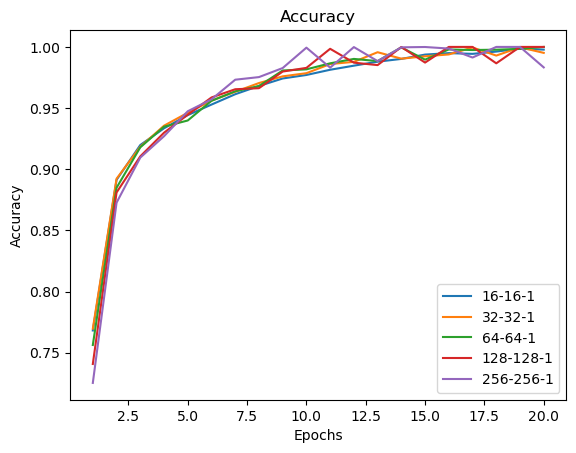

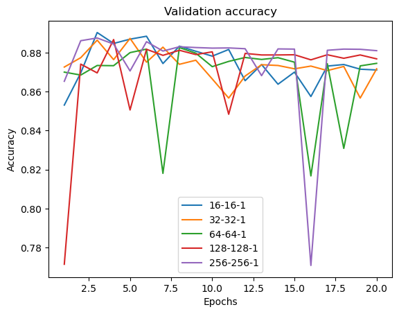

```python
#declare networks according to "histories[model_name]"
net_a, net_b, net_c, net_d, net_e, = '16-16-1', '32-32-1', '64-64-1', '128-128-1', '256-256-1'
#plotting accuracy
plot_acc_comparison(acc_a=histories[net_a].history['accuracy'], label_a=net_a,
                     acc_b=histories[net_b].history['accuracy'], label_b=net_b,
                     acc_c=histories[net_c].history['accuracy'], label_c=net_c,
                    acc_d=histories[net_d].history['accuracy'], label_d=net_d,
                    acc_e=histories[net_e].history['accuracy'], label_e=net_e, y_label='Accuracy')
#plotting validation accuracy
plot_val_acc_comparison(val_acc_a=histories[net_a].history['val_accuracy'], label_a=net_a,
                     val_acc_b=histories[net_b].history['val_accuracy'], label_b=net_b,
                     val_acc_c=histories[net_c].history['val_accuracy'], label_c=net_c,
                        val_acc_d=histories[net_d].history['val_accuracy'], label_d=net_d,
                        val_acc_e=histories[net_e].history['val_accuracy'], label_e=net_e, y_label='Accuracy')
```

**Accuracy plots interpetation**

Accuracy and validation accuracy performed similarly for all 5 models. Not much noticeable variance can be noted.

### Loss and validation loss

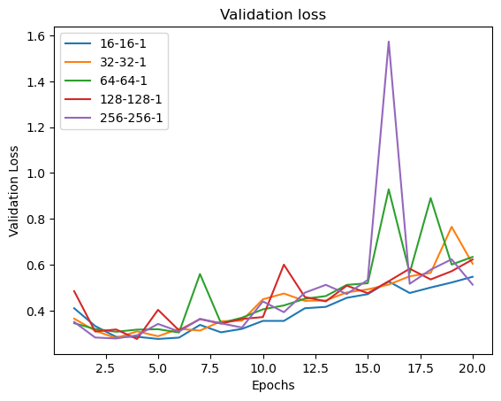

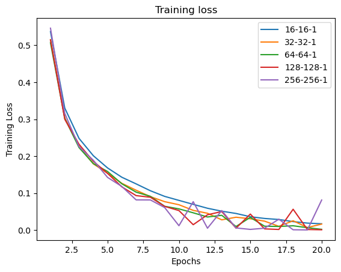

```python
# plotting loss and validation loss
plot_loss_comparison(loss_a=histories[net_a].history['val_loss'], label_a=net_a,
                     loss_b=histories[net_b].history['val_loss'], label_b=net_b,
                     loss_c=histories[net_c].history['val_loss'], label_c=net_c,
                     loss_d=histories[net_d].history['val_loss'], label_d=net_d,
                     loss_e=histories[net_e].history['val_loss'], label_e=net_e,
                        y_label='Validation Loss')

plot_training_loss_comparison(tloss_a=histories[net_a].history['loss'], label_a=net_a,
                     tloss_b=histories[net_b].history['loss'], label_b=net_b,
                     tloss_c=histories[net_c].history['loss'], label_c=net_c,
                    tloss_d=histories[net_d].history['loss'], label_d=net_d,
                    tloss_e=histories[net_e].history['loss'], label_e=net_e,
                        y_label='Training Loss')
```

**Loss and validation loss interpretation**

Validation loss shows that some models overtrain earlier, and some models will overtrain harder.

Training loss steadily declines for all models regardless of size.

### Plotting training and validation accuracy as well as loss of a few interesting models

We will start to examine the data for the middle range of networks -- 32, 64, and 128.

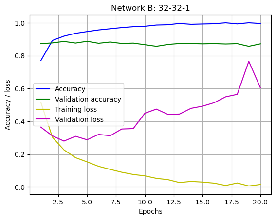

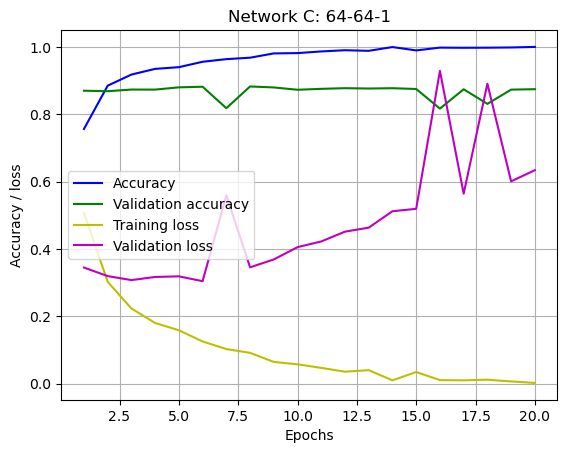

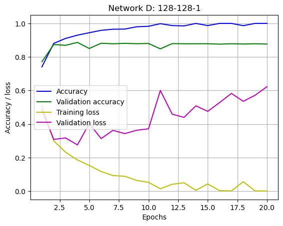

```python
# selecting network b, c, d
plot_net_b(acc=histories[net_b].history['accuracy'], label_a="Accuracy",
           val_acc=histories[net_b].history['val_accuracy'], label_b="Validation accuracy",
            tloss=histories[net_b].history['loss'], label_c="Training loss",
            loss=histories[net_b].history['val_loss'], label_d="Validation loss", y_label='Accuracy / loss')

plot_net_c(acc=histories[net_c].history['accuracy'], label_a="Accuracy",
            val_acc=histories[net_c].history['val_accuracy'], label_b="Validation accuracy",
            tloss=histories[net_c].history['loss'], label_c="Training loss",
            loss=histories[net_c].history['val_loss'], label_d="Validation loss", y_label='Accuracy / loss')

plot_net_d(acc=histories[net_d].history['accuracy'], label_a="Accuracy",
            val_acc=histories[net_d].history['val_accuracy'], label_b="Validation accuracy",
            tloss=histories[net_d].history['loss'], label_c="Training loss",
            loss=histories[net_d].history['val_loss'], label_d="Validation loss", y_label='Accuracy / loss')
```

**Network b, c, d interpretation**

**Overfitting**

Overfitting is when the model performs well on the training data, but performs poorly on test, validation, or unseen data. This is because the model becomes too specialized in solving the training data, and it can be said that the model memorizes the training data. This causes it to perform poorly on unseen datasets.

The overfitting of the models is quite clear in these 3 examples. By looking at the training and validation loss curves, we can see that there is a divergence early on in all 3 models.

To explain, the training loss curve decreases at a normal rate reaching near 0 by the end.

### Lets try adding more layers

Let’s try to add more layers and see if the model overtrains faster or more severely. We will add 1 more hidden relu layer and observe the results.

```python
# define model
def build_model(layer_1_units, layer_2_units, layer_3_units, layer_4_units):
    model = models.Sequential()
    model.add(layers.Dense(layer_1_units, activation='relu', input_shape=(10000,)))
    model.add(layers.Dense(layer_2_units, activation='relu'))
    model.add(layers.Dense(layer_3_units, activation='relu'))
    model.add(layers.Dense(layer_4_units, activation='sigmoid'))
    model.compile(optimizer='rmsprop',
        loss='binary_crossentropy',
        metrics=['accuracy'])
    return model

class CustomCallback(tf.keras.callbacks.Callback):
    def on_epoch_begin(self, epoch, logs=None):
        c = ['\b|', '\b/', '\b-', '\b\\']
        print(c[epoch % 4], end='')
    def on_epoch_end(self, epoch, logs=None):
        print('\b', end='')
```

```python
histories = {}
for i in [16, 32, 64, 128, 256]:
    model = build_model(i, i, i, 1)
    model_name = str(i) + '-' + str(i) + '-' + str(i) + '-' + str(1)
    print('Training', model_name)
    history = model.fit(partial_x_train,
                       partial_y_train,
                        epochs=20,
                        batch_size=512,
                        validation_data=(x_val, y_val),
                        verbose = 0,
                        callbacks = [CustomCallback()])
    histories[model_name] = history
    model.summary()
    model.reset_states()
```

```
Training 16-16-16-1
Model: "sequential_6"
_________________________________________________________________
 Layer (type)                Output Shape              Param #
=================================================================
 dense_17 (Dense)            (None, 16)                160016

 dense_18 (Dense)            (None, 16)                272

 dense_19 (Dense)            (None, 16)                272

 dense_20 (Dense)            (None, 1)                 17

=================================================================
Total params: 160577 (627.25 KB)
Trainable params: 160577 (627.25 KB)
Non-trainable params: 0 (0.00 Byte)
_________________________________________________________________
Training 32-32-32-1
Model: "sequential_7"
_________________________________________________________________
 Layer (type)                Output Shape              Param #
=================================================================
 dense_21 (Dense)            (None, 32)                320032

 dense_22 (Dense)            (None, 32)                1056

 dense_23 (Dense)            (None, 32)                1056

 dense_24 (Dense)            (None, 1)                 33

=================================================================
Total params: 322177 (1.23 MB)
Trainable params: 322177 (1.23 MB)
Non-trainable params: 0 (0.00 Byte)
_________________________________________________________________
Training 64-64-64-1
Model: "sequential_8"
_________________________________________________________________
 Layer (type)                Output Shape              Param #
```

[output cut: 35 more lines]

```
 Layer (type)                Output Shape              Param #
=================================================================
 dense_33 (Dense)            (None, 256)               2560256

 dense_34 (Dense)            (None, 256)               65792

 dense_35 (Dense)            (None, 256)               65792

 dense_36 (Dense)            (None, 1)                 257

=================================================================
Total params: 2692097 (10.27 MB)
Trainable params: 2692097 (10.27 MB)
Non-trainable params: 0 (0.00 Byte)
_________________________________________________________________
```

```python
history_dict = history.history
```

### Validation loss

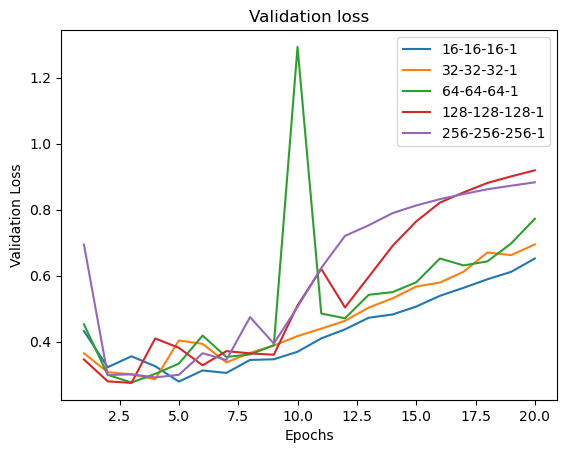

```python
#declare networks according to "histories[model_name]"
net_a, net_b, net_c, net_d, net_e, = '16-16-16-1', '32-32-32-1', '64-64-64-1', '128-128-128-1', '256-256-256-1'
#plotting validation loss
plot_loss_comparison(loss_a=histories[net_a].history['val_loss'], label_a=net_a,
                     loss_b=histories[net_b].history['val_loss'], label_b=net_b,
                     loss_c=histories[net_c].history['val_loss'], label_c=net_c,
                     loss_d=histories[net_d].history['val_loss'], label_d=net_d,
                     loss_e=histories[net_e].history['val_loss'], label_e=net_e,
                        y_label='Validation Loss')
```

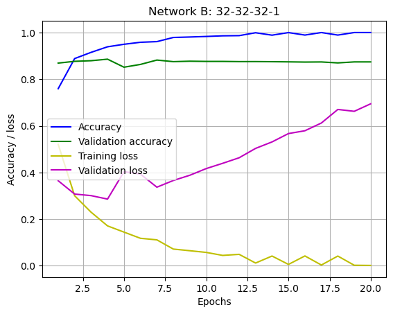

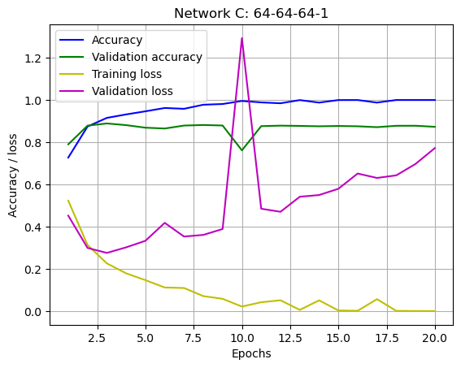

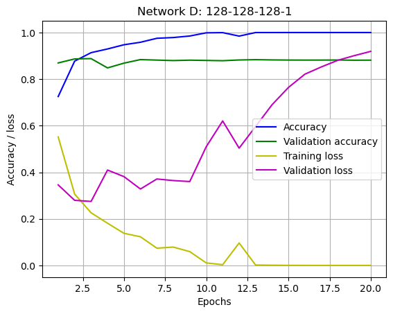

```python
# plotting training and validation accuracy as well as loss of a few interesting models

plot_net_b(acc=histories[net_b].history['accuracy'], label_a="Accuracy",
           val_acc=histories[net_b].history['val_accuracy'], label_b="Validation accuracy",
            tloss=histories[net_b].history['loss'], label_c="Training loss",
            loss=histories[net_b].history['val_loss'], label_d="Validation loss", y_label='Accuracy / loss')

plot_net_c(acc=histories[net_c].history['accuracy'], label_a="Accuracy",
            val_acc=histories[net_c].history['val_accuracy'], label_b="Validation accuracy",
            tloss=histories[net_c].history['loss'], label_c="Training loss",
            loss=histories[net_c].history['val_loss'], label_d="Validation loss", y_label='Accuracy / loss')
plot_net_d(acc=histories[net_d].history['accuracy'], label_a="Accuracy",
           val_acc=histories[net_d].history['val_accuracy'], label_b="Validation accuracy",
            tloss=histories[net_d].history['loss'], label_c="Training loss",
            loss=histories[net_d].history['val_loss'], label_d="Validation loss", y_label='Accuracy / loss')
```

The result of adding another hidden layer is quite evident. We can see that the model is overtraining more severely as all 3 models of interest and went over 0.6 validation loss at the end. The previous 3 hidden layer model barley reached or did not go over 0.6 by the end of 20 epochs.

### Statistical power and overtraining achieved

The 4 hidden layer model can meet the requirements and we can move to the next phase.

## 7. Regularizing your model and tuning your hyperparameters

### Dropout layers

Moving on to the next phase of taming the overfitting of the batch of models from the previous section. Lets start by adding some dropout layers between the relu layers. It is recommended to use a number between 0.2 and 0.5, so let’s start high with 0.5.

```python
# define model
def build_model(layer_1_units, layer_2_units, layer_3_units, layer_4_units):
    model = models.Sequential()
    model.add(layers.Dense(layer_1_units, activation='relu', input_shape=(10000,)))
    model.add(layers.Dropout(0.5))
    model.add(layers.Dense(layer_2_units, activation='relu'))
    model.add(layers.Dropout(0.5))
    model.add(layers.Dense(layer_3_units, activation='relu'))
    model.add(layers.Dropout(0.5))
    model.add(layers.Dense(layer_4_units, activation='sigmoid'))
    model.compile(optimizer='rmsprop',
        loss='binary_crossentropy',
        metrics=['accuracy'])
    return model

class CustomCallback(tf.keras.callbacks.Callback):
    def on_epoch_begin(self, epoch, logs=None):
        c = ['\b|', '\b/', '\b-', '\b\\']
        print(c[epoch % 4], end='')
    def on_epoch_end(self, epoch, logs=None):
        print('\b', end='')
```

```python
histories = {}
model.reset_states()
for i in [16, 32, 64, 128, 256]:
    model = build_model(i, i, i, 1)
    model_name = str(i) + '-' + str(i) + '-' + str(i) + '-' + str(1)
    print('Training', model_name)
    history = model.fit(partial_x_train,
                       partial_y_train,
                        epochs=20,
                        batch_size=512,
                        validation_data=(x_val, y_val),
                        verbose = 0,
                        callbacks = [CustomCallback()])
    histories[model_name] = history
    model.summary()
```

```
Training 16-16-16-1
Model: "sequential_34"
_________________________________________________________________
 Layer (type)                Output Shape              Param #
=================================================================
 dense_129 (Dense)           (None, 16)                160016

 dropout_69 (Dropout)        (None, 16)                0

 dense_130 (Dense)           (None, 16)                272

 dropout_70 (Dropout)        (None, 16)                0

 dense_131 (Dense)           (None, 16)                272

 dropout_71 (Dropout)        (None, 16)                0

 dense_132 (Dense)           (None, 1)                 17

=================================================================
Total params: 160577 (627.25 KB)
Trainable params: 160577 (627.25 KB)
Non-trainable params: 0 (0.00 Byte)
_________________________________________________________________
Training 32-32-32-1
Model: "sequential_35"
_________________________________________________________________
 Layer (type)                Output Shape              Param #
=================================================================
 dense_133 (Dense)           (None, 32)                320032

 dropout_72 (Dropout)        (None, 32)                0

 dense_134 (Dense)           (None, 32)                1056

 dropout_73 (Dropout)        (None, 32)                0

 dense_135 (Dense)           (None, 32)                1056

 dropout_74 (Dropout)        (None, 32)                0
```

[output cut: 65 more lines]

```
 dense_146 (Dense)           (None, 256)               65792

 dropout_82 (Dropout)        (None, 256)               0

 dense_147 (Dense)           (None, 256)               65792

 dropout_83 (Dropout)        (None, 256)               0

 dense_148 (Dense)           (None, 1)                 257

=================================================================
Total params: 2692097 (10.27 MB)
Trainable params: 2692097 (10.27 MB)
Non-trainable params: 0 (0.00 Byte)
_________________________________________________________________
```

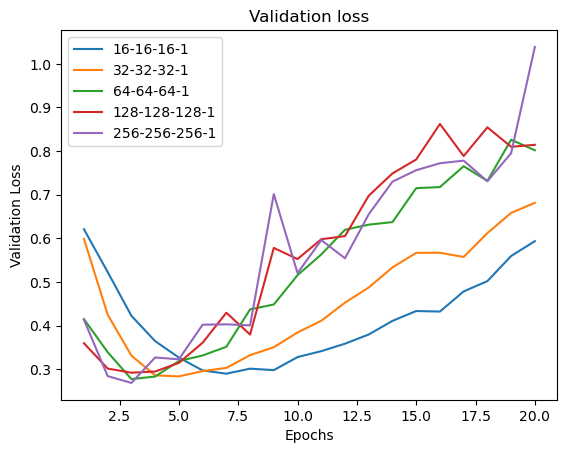

```python
#declare networks according to "histories[model_name]"
net_a, net_b, net_c, net_d, net_e, = '16-16-16-1', '32-32-32-1', '64-64-64-1', '128-128-128-1', '256-256-256-1'
#plotting validation loss
plot_loss_comparison(loss_a=histories[net_a].history['val_loss'], label_a=net_a,
                     loss_b=histories[net_b].history['val_loss'], label_b=net_b,
                     loss_c=histories[net_c].history['val_loss'], label_c=net_c,
                     loss_d=histories[net_d].history['val_loss'], label_d=net_d,
                     loss_e=histories[net_e].history['val_loss'], label_e=net_e,
                        y_label='Validation Loss')
```

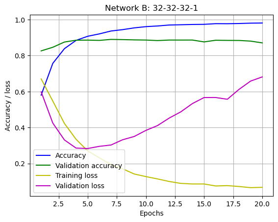

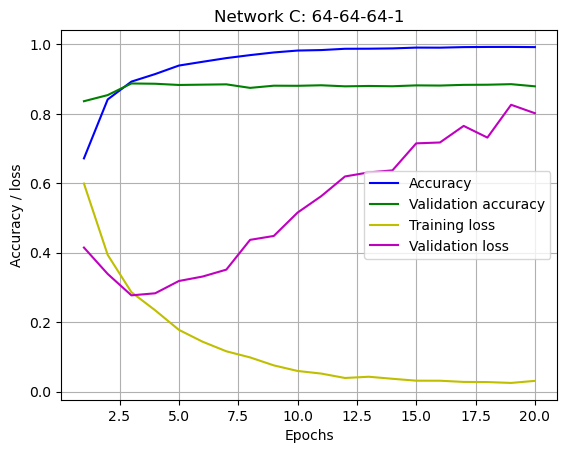

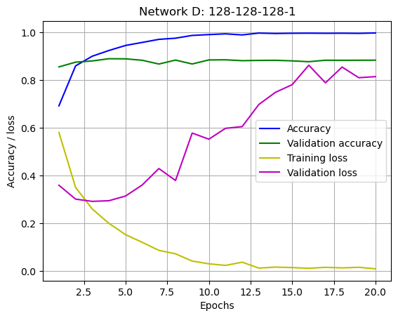

```python
# plotting training and validation accuracy as well as loss of a few interesting models

plot_net_b(acc=histories[net_b].history['accuracy'], label_a="Accuracy",
           val_acc=histories[net_b].history['val_accuracy'], label_b="Validation accuracy",
            tloss=histories[net_b].history['loss'], label_c="Training loss",
            loss=histories[net_b].history['val_loss'], label_d="Validation loss", y_label='Accuracy / loss')

plot_net_c(acc=histories[net_c].history['accuracy'], label_a="Accuracy",
            val_acc=histories[net_c].history['val_accuracy'], label_b="Validation accuracy",
            tloss=histories[net_c].history['loss'], label_c="Training loss",
            loss=histories[net_c].history['val_loss'], label_d="Validation loss", y_label='Accuracy / loss')
plot_net_d(acc=histories[net_d].history['accuracy'], label_a="Accuracy",
           val_acc=histories[net_d].history['val_accuracy'], label_b="Validation accuracy",
            tloss=histories[net_d].history['loss'], label_c="Training loss",
            loss=histories[net_d].history['val_loss'], label_d="Validation loss", y_label='Accuracy / loss')
```

**Interpretation**

The effect seen from the aggressive dropout did have some effect, but not a very noticeable one. We can see that it benefited the smaller networks more, and we can see that the overfitting happened later for the 16-16-16-1 network. The drop in validation loss was also also steeper, with all networks showing a more spread out grouping.

Perhaps we need to combine more regularization methods to better tame the overfitting.

**Focus on the smaller networks**

At this point, it is noticed that the larger networks are overfitting more severely for our problem, so we will just focus on the smaller networks as they would be easier to tame. The end result will most definitely not use one of the larger models.

### Weight regularization

As stated in the DLWP 4.4.2, there are two kinds of weight regularization:

- L1 regularization
- L2 regularization

There are options to try either one or both at the same time with the network. We will start with L1 first.

### L1 regularization

```python
# define model
def build_model(layer_1_units, layer_2_units, layer_3_units, layer_4_units):
    model = models.Sequential()
    model.add(layers.Dense(layer_1_units, kernel_regularizer=regularizers.l1(0.001), activation='relu', input_shape=(10000,)))
    model.add(layers.Dropout(0.5))
    model.add(layers.Dense(layer_2_units, kernel_regularizer=regularizers.l1(0.001), activation='relu'))
    model.add(layers.Dropout(0.5))
    model.add(layers.Dense(layer_3_units, kernel_regularizer=regularizers.l1(0.001), activation='relu'))
    model.add(layers.Dropout(0.5))
    model.add(layers.Dense(layer_4_units, activation='sigmoid'))
    model.compile(optimizer='rmsprop',
        loss='binary_crossentropy',
        metrics=['accuracy'])
    return model

class CustomCallback(tf.keras.callbacks.Callback):
    def on_epoch_begin(self, epoch, logs=None):
        c = ['\b|', '\b/', '\b-', '\b\\']
        print(c[epoch % 4], end='')
    def on_epoch_end(self, epoch, logs=None):
        print('\b', end='')
```

```python
histories = {}
model.reset_states()
for i in [16, 32, 64, 128, 256]:
    model = build_model(i, i, i, 1)
    model_name = str(i) + '-' + str(i) + '-' + str(i) + '-' + str(1)
    print('Training', model_name)
    history = model.fit(partial_x_train,
                       partial_y_train,
                        epochs=20,
                        batch_size=512,
                        validation_data=(x_val, y_val),
                        verbose = 0,
                        callbacks = [CustomCallback()])
    histories[model_name] = history
    model.summary()
```

```
Training 16-16-16-1
Model: "sequential_42"
_________________________________________________________________
 Layer (type)                Output Shape              Param #
=================================================================
 dense_161 (Dense)           (None, 16)                160016

 dropout_93 (Dropout)        (None, 16)                0

 dense_162 (Dense)           (None, 16)                272

 dropout_94 (Dropout)        (None, 16)                0

 dense_163 (Dense)           (None, 16)                272

 dropout_95 (Dropout)        (None, 16)                0

 dense_164 (Dense)           (None, 1)                 17

=================================================================
Total params: 160577 (627.25 KB)
Trainable params: 160577 (627.25 KB)
Non-trainable params: 0 (0.00 Byte)
_________________________________________________________________
Training 32-32-32-1
Model: "sequential_43"
_________________________________________________________________
 Layer (type)                Output Shape              Param #
=================================================================
 dense_165 (Dense)           (None, 32)                320032

 dropout_96 (Dropout)        (None, 32)                0

 dense_166 (Dense)           (None, 32)                1056

 dropout_97 (Dropout)        (None, 32)                0

 dense_167 (Dense)           (None, 32)                1056

 dropout_98 (Dropout)        (None, 32)                0
```

[output cut: 65 more lines]

```
 dense_178 (Dense)           (None, 256)               65792

 dropout_106 (Dropout)       (None, 256)               0

 dense_179 (Dense)           (None, 256)               65792

 dropout_107 (Dropout)       (None, 256)               0

 dense_180 (Dense)           (None, 1)                 257

=================================================================
Total params: 2692097 (10.27 MB)
Trainable params: 2692097 (10.27 MB)
Non-trainable params: 0 (0.00 Byte)
_________________________________________________________________
```

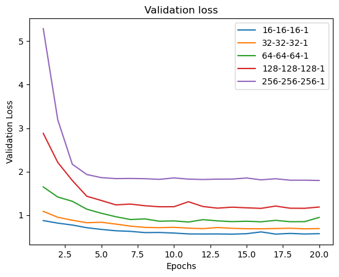

```python
#declare networks according to "histories[model_name]"
net_a, net_b, net_c, net_d, net_e, = '16-16-16-1', '32-32-32-1', '64-64-64-1', '128-128-128-1', '256-256-256-1'
#plotting validation loss
plot_loss_comparison(loss_a=histories[net_a].history['val_loss'], label_a=net_a,
                     loss_b=histories[net_b].history['val_loss'], label_b=net_b,
                     loss_c=histories[net_c].history['val_loss'], label_c=net_c,
                     loss_d=histories[net_d].history['val_loss'], label_d=net_d,
                     loss_e=histories[net_e].history['val_loss'], label_e=net_e,
                        y_label='Validation Loss')
```

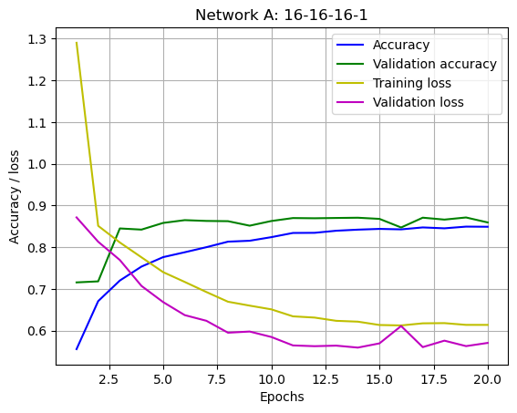

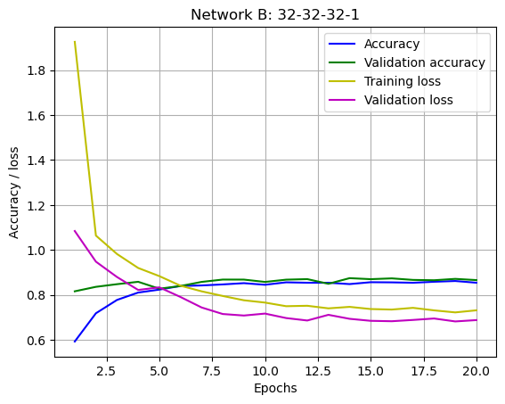

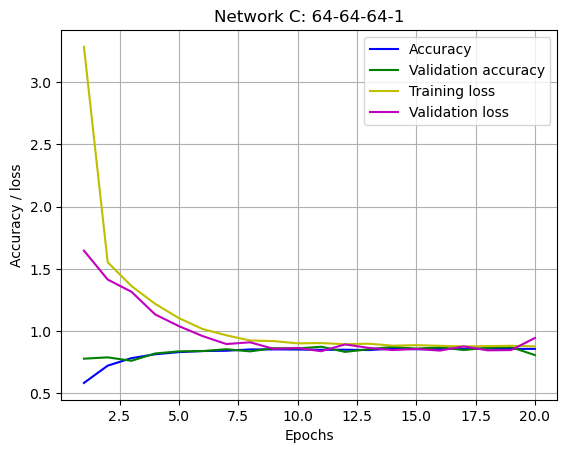

```python
# plotting training and validation accuracy as well as loss of a few interesting models
plot_net_a(acc=histories[net_a].history['accuracy'], label_a="Accuracy",
           val_acc=histories[net_a].history['val_accuracy'], label_b="Validation accuracy",
            tloss=histories[net_a].history['loss'], label_c="Training loss",
            loss=histories[net_a].history['val_loss'], label_d="Validation loss", y_label='Accuracy / loss')
plot_net_b(acc=histories[net_b].history['accuracy'], label_a="Accuracy",
           val_acc=histories[net_b].history['val_accuracy'], label_b="Validation accuracy",
            tloss=histories[net_b].history['loss'], label_c="Training loss",
            loss=histories[net_b].history['val_loss'], label_d="Validation loss", y_label='Accuracy / loss')
plot_net_c(acc=histories[net_c].history['accuracy'], label_a="Accuracy",
            val_acc=histories[net_c].history['val_accuracy'], label_b="Validation accuracy",
            tloss=histories[net_c].history['loss'], label_c="Training loss",
            loss=histories[net_c].history['val_loss'], label_d="Validation loss", y_label='Accuracy / loss')
```

**Interpretation**

Not quite sure how to interpret the results, or maybe it is not the correct method for what we are working on, but let’s move on to L2 and see if something else happens.